# Diversity tutorial多样性分析教程

Yong-Xin Liu(刘永鑫), Tao Wen(文涛), Tong Chen(陈同)

2024-03-21

If you use this script, please cited 如果你使用本代码，请引用：

**Yong-Xin Liu**, Lei Chen, Tengfei Ma, Xiaofang Li, Maosheng Zheng, Xin Zhou, Liang Chen, Xubo Qian, Jiao Xi, Hongye Lu, Huiluo Cao, Xiaoya Ma, Bian Bian, Pengfan Zhang, Jiqiu Wu, Ren-You Gan, Baolei Jia, Linyang Sun, Zhicheng Ju, Yunyun Gao, **Tao Wen**, **Tong Chen**. 2023. EasyAmplicon: An easy-to-use, open-source, reproducible, and community-based pipeline for amplicon data analysis in microbiome research. **iMeta** 2(1): e83. https://doi.org/10.1002/imt2.83

# Introduction简介

## Installation安装

The [amplicon R package](https://github.com/microbiota) facilitates statistics and visualization of amplicon profiling data, in particular 16S and ITS alpha / beta diversity, and taxonomy composition.

```r
# 基于CRAN安装R包，检测没有则安装
p_list = c("ggplot2", "BiocManager", "devtools")
for(p in p_list){if (!requireNamespace(p)){install.packages(p)}
    library(p, character.only = TRUE, quietly = TRUE, warn.conflicts = FALSE)}

# 基于Bioconductor安装R包
if (!requireNamespace("ggtree", quietly = TRUE))
    BiocManager::install("ggtree")

# 基于github安装
library(devtools)
if(!requireNamespace("amplicon", quietly = TRUE))
  install_github("microbiota/amplicon")

# 加载R包 Load the package
suppressWarnings(suppressMessages(library(amplicon)))
```

## 实验设计 Design/Metadata

设置基本参数：读取实验设计、设置分组列名、图片宽高

Setting the basic parameter

```r
# Data reading
metadata = read.table("metadata.txt", header=T, row.names=1, sep="\t", comment.char="", stringsAsFactors = F)
head(metadata, n = 3)
```

|  | Group | Date | Site | CRA | CRR | BarcodeSequence | LinkerPrimerSequence | ReversePrimer | Batch | Species | Sequencing | Platform | latitude_longitude | Description |
| --- | --- | --- | --- | --- | --- | --- | --- | --- | --- | --- | --- | --- | --- | --- |
| KO1 | KO | 2017/6/30 | Chaoyang | CRA002352 | CRR117575 | ACGCTCGACA | AACMGGATTAGATACCCKG | ACGTCATCCCCACCTTCC | 1 | Arabidopsis thaliana | Novagene | HiSeq2500 | 39.59 N 116.22 E | Knock-out replicate 1 |
| KO2 | KO | 2017/6/30 | Chaoyang | CRA002352 | CRR117576 | ATCAGACACG | AACMGGATTAGATACCCKG | ACGTCATCCCCACCTTCC | 1 | Arabidopsis thaliana | Novagene | HiSeq2500 | 39.59 N 116.22 E | Knock-out replicate 2 |
| KO3 | KO | 2017/7/2 | Changping | CRA002352 | CRR117577 | ATATCGCGAG | AACMGGATTAGATACCCKG | ACGTCATCCCCACCTTCC | 1 | Arabidopsis thaliana | Novagene | HiSeq2500 | 40.10 N 116.42 E | Knock-out replicate 3 |

```r
# colnames of group ID in metadata
# 设置实验分组列名
group = "Group"
# Output figure width and height
# Letter纸图片尺寸为单栏89 mm，双栏183 mm，页面最宽为247 mm
# 推荐比例16：10，即半版89 mm x 56 mm; 183 mm x 114 mm
width = 89
height = 59

# 手动指定分组列和顺序，默认为字母顺序
metadata[[group]] = factor(metadata[[group]], levels = c("WT","KO","OE"))
# 按实验设计中分组出现顺序
# metadata[[group]] = factor(metadata[[group]], levels = unique(metadata[[group]]))
```

# Alpha diversityα多样性

## Boxplot+Statistics箱线图+统计

Plotting each figure mainly include three step: 绘制主要分三步：

1. Reading data and viewing format读取数据并预览格式;
2. Paramters adjustment and plotting参数调整和绘图;
3. Saving figure保存图片.

```r
# vegan.txt include 6 alpha index，alpha.txt include 11 alpha index
alpha_div = read.table("alpha/vegan.txt", header=T, row.names=1, sep="\t", comment.char="")
head(alpha_div, n = 3)
```

|  | richness | chao1 | ACE | shannon | simpson | invsimpson |
| --- | --- | --- | --- | --- | --- | --- |
| KO1 | 1089 | 1259.680 | 1250.531 | 5.836145 | 0.9896903 | 96.99641 |
| KO2 | 1088 | 1229.984 | 1242.045 | 5.952251 | 0.9932809 | 148.82857 |
| KO3 | 945 | 1173.864 | 1167.303 | 5.521811 | 0.9877688 | 81.75826 |

```r
# capitalize
library(Hmisc)
colnames(alpha_div) = capitalize(colnames(alpha_div))
colnames(alpha_div)
```

```
#> [1] "Richness"   "Chao1"      "ACE"        "Shannon"    "Simpson"
#> [6] "Invsimpson"
```

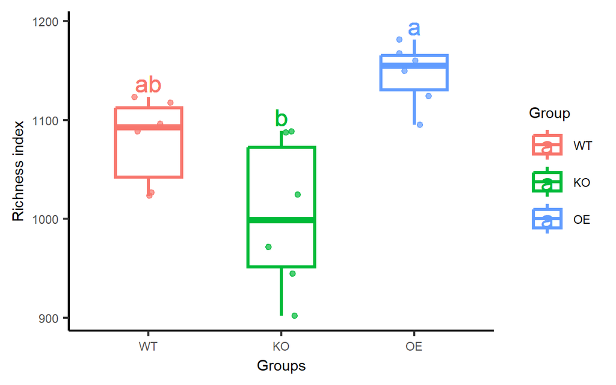

```r
# Select one of index "Richness","Chao1","ACE","Shannon","Simpson","Invsimpson"
alpha_index = "Richness"

# Plotting alpha diversity Richness boxplot and stat
(p = alpha_boxplot(alpha_div, index = alpha_index, metadata, groupID = group))
```

```r
# Remove legend 去除图例
p = p + theme(legend.position = "NA")
# Saving figure 保存图片，大家可以修改图片名称和位置，长宽单位为毫米
ggsave(paste0("alpha/alpha_boxplot_",alpha_index,".pdf"), p, width = width, height = height, units = "mm")
# Save for cowplot 另存图片用于后期拼图
p1 = p

# Try another index, such as Shannon, 尝试探索不同的多样性种类
colnames(alpha_div)
```

```
#> [1] "Richness"   "Chao1"      "ACE"        "Shannon"    "Simpson"
#> [6] "Invsimpson"
```

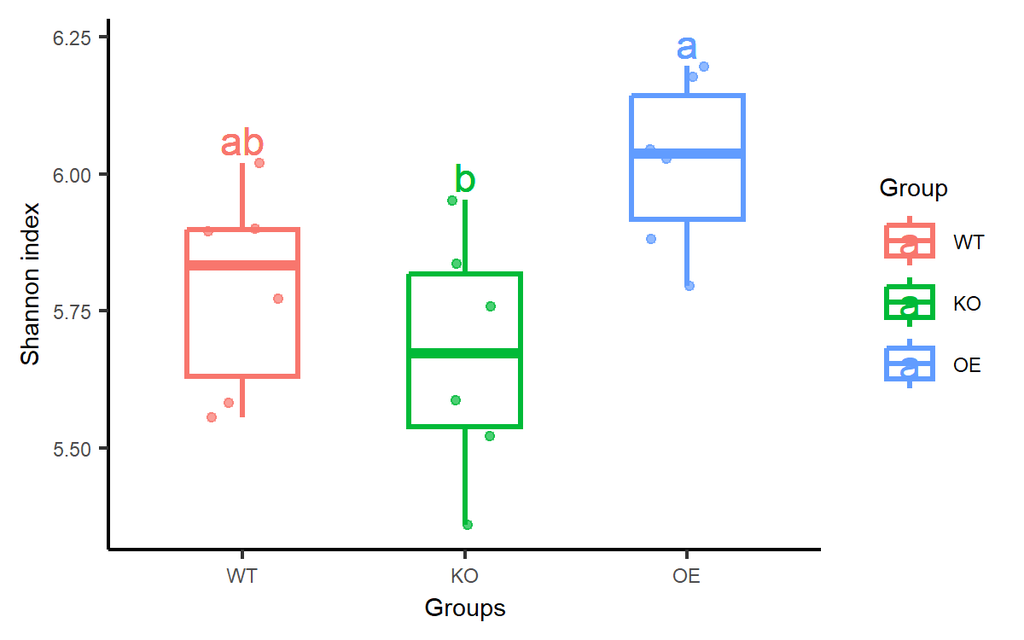

```r
alpha_boxplot(alpha_div, index = "Shannon", metadata, groupID = group)
```

```r
# Try different group 尝试不同的分组方式
colnames(metadata)
```

```
#>  [1] "Group"                "Date"                 "Site"
#>  [4] "CRA"                  "CRR"                  "BarcodeSequence"
#>  [7] "LinkerPrimerSequence" "ReversePrimer"        "Batch"
#> [10] "Species"              "Sequencing"           "Platform"
#> [13] "latitude_longitude"   "Description"
```

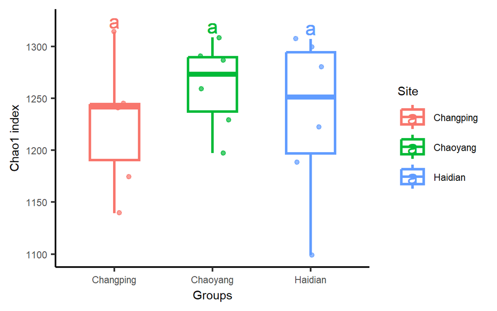

```r
alpha_boxplot(alpha_div, index = "Chao1", metadata, groupID = "Site")
```

## Rarefaction curve and standard error稀释曲线+标准误

```r
# Data reading数据读取
alpha_rare = read.table("alpha/alpha_rare.txt", header=T, row.names=1, sep="\t", comment.char="")
alpha_rare[1:3, 1:3]
```

|  | KO1 | KO2 | KO3 |
| --- | --- | --- | --- |
| 1 | 34 | 36 | 40 |
| 2 | 80 | 83 | 82 |
| 3 | 122 | 135 | 123 |

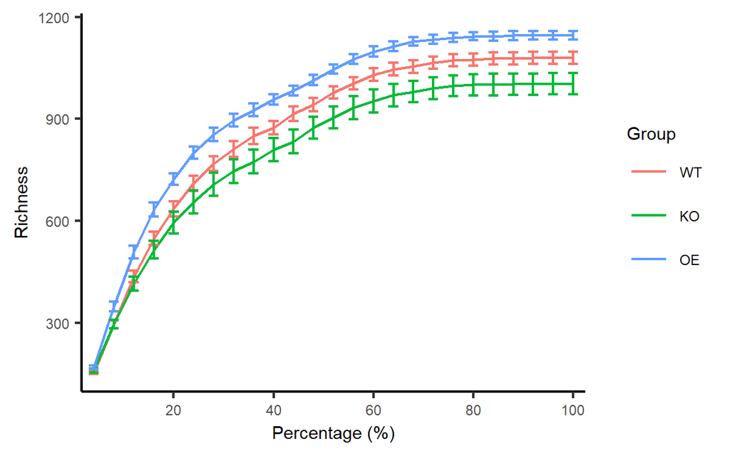

```r
# Plotting alpha rarefaction curve in group mean with standard error绘制稀释曲线+标准误
(p = alpha_rare_curve(alpha_rare, metadata, groupID = group))
```

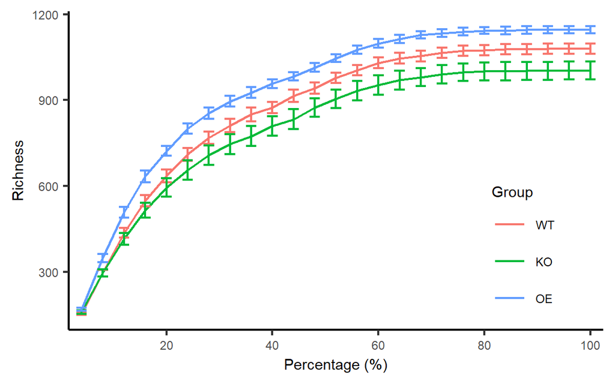

```r
# Legend to low right 图例移至右下
(p = p + theme(legend.position = c(0.85,0.25)))
```

```r
# Saving figure保存图片
ggsave("alpha/alpha_rarefaction_curve.pdf", p, width = width, height = height, units = "mm")
p2 = p
```

## 各组多样性种组比较 Venn/Upset/Sanky

命令行 sp_vennDiagram.sh 绘制维恩图

推荐使用`otu_group_exist.txt`在线 http://www.ehbio.com/ImageGP 绘制Venn/Upset/Sanky